# Домашнее задание по Автоматизации обработки данных

Authors

[Ситькова Дарья Александровна](https://github.com/SitkovaDarya)

[Василий Садовин](https://github.com/Gromoron)

[Виктория Гаврилова](https://github.com/vicoso)

Вариант 14. В отчете рассматриваются две группы лечения: Placebo и Xanomeline High Dose. Из лабораторных показателей анализируются HGB, VITB12 на визите SCREENING 1. На визите SCREENING 1 и WEEK 4 анализируется вес (WEIGHT). Анализируется генотип APOE для каждого участника.

## 1. Импорт и очистка данных

### 1.1. Пациенты

```r
dm_all <- read_csv("data/dm.csv")
```

dm.csv — широкий формат, потому что каждая строка соответствует одному участнику (уникальный USUBJID встречается один раз), а разные признаки — возраст AGE, пол SEX, группа лечения ARM — лежат в отдельных столбцах.

```r
dm1 <- select(dm_all, USUBJID, AGE, SEX, ARM)
dm <- rename(dm1, ID = USUBJID)
```

```r
counts <- count(dm, ID)
repeats <- filter(counts, n > 1)
if (nrow(repeats) > 0) {
  print(repeats)
  stop()
}
```

```r
nrow(dm_all)
```

```
[1] 306
```

```r
table(is.na(dm_all$ARM) | dm_all$ARM == "Screen Failure")
```

```
FALSE  TRUE
  254    52
```

```r
screen_failure <- sum(is.na(dm_all$ARM) | dm_all$ARM == "Screen Failure")
screen_failure
```

```
[1] 52
```

```r
percent_screen_failure <- 100 * screen_failure / nrow(dm_all)
percent_screen_failure
```

```
[1] 16.99346
```

```r
dm_filtered <- filter(dm, ARM == "Placebo" | ARM == "Xanomeline High Dose")
dm_filtered <- mutate(
  dm_filtered,
  ARM = factor(ARM, levels = c("Placebo", "Xanomeline High Dose"))
)
table(dm_filtered$ARM)
```

```
             Placebo Xanomeline High Dose
                  86                   84
```

```r
dm <- dm_filtered
```

### 1.2. Лабораторные измерения

3. На каких визитах выполняли измерения и какие лабораторные показатели измеряли? Отдельно выведите или подчеркните визиты, на которых измеряли витамин B12.

```r
lb_all <- read_csv("data/lb.csv")
```

lb_all - длинный формат, потому что одна строка соответствует одному измерению одного лабораторного показателя у одного участника на одном визите.

```r
lb1 <- select(lb_all, USUBJID, LBTESTCD, LBSTRESN, VISIT)
```

```r
lb1 <- rename(lb1, ID = USUBJID)
```

```r
lb_counts <- count(lb1, ID)
summary(lb_counts$n)
```

```
   Min. 1st Qu.  Median    Mean 3rd Qu.    Max.
   9.00   34.00   50.00   41.55   50.00   58.00
```

Минимальное число строк на пациента 9, максимальное число строк 58.

```r
distinct(lb1, VISIT)
```

```
# A tibble: 7 × 1
  VISIT
  <chr>
1 WEEK 4
2 WEEK 6
3 WEEK 8
4 WEEK 12
5 SCREENING 1
6 WEEK 2
7 BASELINE
```

```r
distinct(lb1, LBTESTCD)
```

```
# A tibble: 10 × 1
   LBTESTCD
   <chr>
 1 BASO
 2 EOS
 3 HGB
 4 LYM
 5 MONO
 6 PLAT
 7 RBC
 8 TSH
 9 VITB12
10 WBC
```

```r
lb_vitb12 <- filter(lb1, LBTESTCD == "VITB12")
distinct(lb_vitb12, VISIT)
```

```
# A tibble: 1 × 1
  VISIT
  <chr>
1 SCREENING 1
```

Лабораторные измерения проводились на визитах SCREENING 1, BASELINE, WEEK 2, WEEK 4, WEEK 6, WEEK 8 и WEEK 12. В данных представлены измерения следующих показателей: BASO (базофилы), EOS (эозинофилы), HGB (гемоглобин), LYM (лимфоциты), MONO (моноциты), PLAT (тромбоциты), RBC (эритроциты), TSH (тиреотропный гормон), VITB12 (витамин B12) и WBC (лейкоциты). Витамин B12 измерялся только на визите SCREENING 1.

```r
lb_team <- semi_join(lb1, dm, by = "ID")
```

```r
lb_team <- filter(
  lb_team,
  (LBTESTCD == "HGB" | LBTESTCD == "VITB12"),
  VISIT == "SCREENING 1"
)
```

```r
table(lb_team$LBTESTCD)
```

```
   HGB VITB12
   166    167
```

После фильтрации осталось 166 измерений гемоглобина (HGB) и 167 измерений витамина В12 (VITB12)

```r
lb_wide <- pivot_wider(
  lb_team,
  id_cols = ID,
  names_from = LBTESTCD,
  values_from = LBSTRESN
)
```

```r
lb_check <- count(lb_wide, ID)
lb_repeats <- filter(lb_check, n > 1)
if (nrow(lb_repeats) > 0) {
  print(lb_repeats)
  stop("В lb_wide есть дублирующиеся ID")
}
```

### 1.3. Витальные показатели

```r
# read_csv
# select, rename
# count

vit_data <- read_csv("data/vs.csv")
table(vit_data$USUBJID)
```

[output not shown]

[output cut: 31 more lines]

[output not shown]

```r
# сколько строк на одного пациента USUBJID
vit_data %>% count(USUBJID)
```

```
# A tibble: 254 × 2
   USUBJID         n
   <chr>       <int>
 1 01-701-1015    71
 2 01-701-1023    41
 3 01-701-1028    71
 4 01-701-1033    41
 5 01-701-1034    71
 6 01-701-1047    41
 7 01-701-1097    71
 8 01-701-1111    31
 9 01-701-1115    61
10 01-701-1118    71
# ℹ 244 more rows
```

```r
#'''
#у нас пациенты занимают больше одной строки, значит это long-формат
#'''

# Какое минимальное и максимальное число строк на одного участника?
range(table(vit_data$USUBJID))
```

```
[1] 21 71
```

```r
# min - 21, max - 71

# На каких визитах измеряли рост (`HEIGHT`) и вес (`WEIGHT`)?
sort(unique(vit_data$VSTEST))
```

```
[1] "Diastolic Blood Pressure" "Height"
[3] "Pulse Rate"               "Systolic Blood Pressure"
[5] "Weight"
```

```r
vit_data %>%
  filter(VSTEST %in% c("Height", "Weight")) %>%
  distinct(VSTEST, VISIT)
```

```
# A tibble: 8 × 2
  VSTEST VISIT
  <chr>  <chr>
1 Height SCREENING 1
2 Weight SCREENING 1
3 Weight BASELINE
4 Weight WEEK 2
5 Weight WEEK 4
6 Weight WEEK 6
7 Weight WEEK 8
8 Weight WEEK 12
```

```r
#'''
#  VSTEST VISIT
#  <chr>  <chr>
#1 Height SCREENING 1
#2 Weight SCREENING 1
#3 Weight BASELINE
#4 Weight WEEK 2
#5 Weight WEEK 4
#6 Weight WEEK 6
#7 Weight WEEK 8
#8 Weight WEEK 12
#'''
```

```r
vit_data_ourpats <- vit_data %>%
  filter(USUBJID %in% dm$ID)
```

```r
vit_data_w4_s1 <- vit_data %>%
  filter(VISIT %in% c("WEEK 4", "SCREENING 1"))
```

```r
vit_data_hw <- vit_data_w4_s1 %>%
  filter(VSTEST %in% c("Weight", "Height"))
```

```r
# переименование в ID
vit_data_hw_id <- vit_data_hw %>%
  rename(
    ID = USUBJID
  )

# перевод в широкий формат
vs_wide <- vit_data_hw_id %>%
  pivot_wider(
    names_from = c(VISIT, VSTEST),
    values_from = VSSTRESN
  )
```

```r
# stopifnot, stop
vs_wide_clean <- vs_wide %>%
  select(ID, `SCREENING 1_Height`, `SCREENING 1_Weight`, `WEEK 4_Weight`)

vs_wide_clean <- vs_wide_clean %>%
  group_by(ID) %>%
  summarise(
    across(everything(), ~ first(na.omit(.))),
    .groups = "drop"
  )

# проверка что ровно одна строка на участника
stopifnot(
  all(table(vs_wide_clean$ID) == 1)
)

# финально переименование
vs_wide <- vs_wide_clean
```

### 1.4. Генотип APOE

```r
gf_raw <- (read.csv("data/gf.csv"))
gf_subset <- select(gf_raw, "USUBJID", GFORRES, GFSYM, GFPVRID, VISIT)
gf_subset <- rename(gf_subset, ID = USUBJID)
gf_subset |> count(ID)
```

```
             ID  n
1   01-701-1015 12
2   01-701-1023 12
3   01-701-1028 12
4   01-701-1033 12
5   01-701-1034 12
6   01-701-1047 12
7   01-701-1097 12
8   01-701-1111 12
9   01-701-1115 12
10  01-701-1118 12
11  01-701-1130 12
12  01-701-1133 12
13  01-701-1146 12
14  01-701-1148 12
```

[output cut: 240 more lines]

```r
gf_subset2 <- gf_subset |>
  left_join(dm, by = "ID") |>
  filter(GFSYM == "APOE" | GFPVRID == "rs429358" | GFPVRID == "rs7412")
```

| rs429358 | rs7412 | Генотип APOE |
| --- | --- | --- |
| T/T | T/T | ε2/ε2 |
| T/T | C/T | ε2/ε3 |
| T/C | C/T | ε2/ε4 |
| T/T | C/C | ε3/ε3 |
| T/C | C/C | ε3/ε4 |
| C/C | C/C | ε4/ε4 |

```r
apoe_genotype <- gf_subset2 |>
  pivot_wider(
    id_cols = c(ID, VISIT, AGE, SEX, ARM),
    names_from = GFPVRID,
    values_from = GFORRES
  )

gf_wide <- mutate(
  apoe_genotype,
  apoe_genotype = case_when(
    rs429358 == "T/T" & rs7412 == "T/T" ~ "ε2/ε2",
    rs429358 == "T/T" & rs7412 == "C/T" ~ "ε2/ε3",
    rs429358 == "T/C" & rs7412 == "C/T" ~ "ε2/ε4",
    rs429358 == "T/T" & rs7412 == "C/C" ~ "ε3/ε3",
    rs429358 == "T/C" & rs7412 == "C/C" ~ "ε3/ε4",
    rs429358 == "C/C" & rs7412 == "C/C" ~ "ε4/ε4",
    TRUE ~ NA_character_
  )
)
count(gf_wide, ID)
```

```
# A tibble: 254 × 2
   ID              n
   <chr>       <int>
 1 01-701-1015     1
 2 01-701-1023     1
 3 01-701-1028     1
 4 01-701-1033     1
 5 01-701-1034     1
 6 01-701-1047     1
 7 01-701-1097     1
 8 01-701-1111     1
 9 01-701-1115     1
10 01-701-1118     1
# ℹ 244 more rows
```

```r
count(gf_wide, apoe_genotype)
```

```
# A tibble: 6 × 2
  apoe_genotype     n
  <chr>         <int>
1 ε2/ε2             1
2 ε2/ε3            31
3 ε2/ε4            11
4 ε3/ε3           105
5 ε3/ε4            97
6 ε4/ε4             9
```

```r
any(duplicated(gf_wide$ID))
```

```
[1] FALSE
```

```r
stopifnot(!any(duplicated(gf_wide$ID)))
```

## 2. Объединение данных

```r
gf_wide1 <- select(gf_wide, ID, rs429358, rs7412, apoe_genotype)

all_data <- left_join(dm, lb_wide, by = "ID")
all_data <- left_join(all_data, vs_wide, by = "ID")
all_data <- left_join(all_data, gf_wide1, by = "ID")
all_data
```

```
# A tibble: 170 × 12
   ID            AGE SEX   ARM                   HGB VITB12 `SCREENING 1_Height`
   <chr>       <dbl> <chr> <fct>               <dbl>  <dbl>                <dbl>
 1 01-701-1015    63 F     Placebo              8.87   294.                 147.
 2 01-701-1023    64 M     Placebo             10.1    408.                 163.
 3 01-701-1028    71 M     Xanomeline High Do… 10.4    186.                 178.
 4 01-701-1034    77 F     Xanomeline High Do…  8.19   437.                 155.
 5 01-701-1047    85 F     Placebo              9.50   432.                 149.
 6 01-701-1118    52 M     Placebo              9.68   213.                 180.
 7 01-701-1130    84 M     Placebo              7.51   262.                 170.
 8 01-701-1133    81 F     Xanomeline High Do…  9.87   212.                 163.
 9 01-701-1146    75 F     Xanomeline High Do…  8.32   281.                 147.
10 01-701-1148    57 M     Xanomeline High Do… 10.2    369.                 175.
# ℹ 160 more rows
# ℹ 5 more variables: `SCREENING 1_Weight` <dbl>, `WEEK 4_Weight` <dbl>,
#   rs429358 <chr>, rs7412 <chr>, apoe_genotype <chr>
```

```r
stopifnot(nrow(all_data) == nrow(dm))
stopifnot(n_distinct(all_data$ID) == nrow(dm))
```

```r
n_missing <- colSums(is.na(all_data))
n_not_missing <- nrow(all_data) - n_missing

n_not_missing
```

```
                ID                AGE                SEX                ARM
               170                170                170                170
               HGB             VITB12 SCREENING 1_Height SCREENING 1_Weight
               166                167                170                170
     WEEK 4_Weight           rs429358             rs7412      apoe_genotype
               154                170                170                170
```

```r
n_missing
```

```
                ID                AGE                SEX                ARM
                 0                  0                  0                  0
               HGB             VITB12 SCREENING 1_Height SCREENING 1_Weight
                 4                  3                  0                  0
     WEEK 4_Weight           rs429358             rs7412      apoe_genotype
                16                  0                  0                  0
```

В таблице all_data 170 строк (по одной на каждого участника). Столбцы ID, AGE, SEX, ARM, SCREENING 1_Height, SCREENING 1_Weight, rs429358, rs7412 и apoe_genotype заполнены полностью. Пропуски есть в лабораторных показателях (HGB — 4, VITB12 — 3) и в весе на визите WEEK 4 (16 пропусков) — это пациенты, у которых нет измерения на соответствующем визите.

## 3. Описательные статистики и отчёт

### 3.1. Анализ лабораторных результатов

```r
lab_arm <- summarise(
  group_by(all_data, ARM),
  HGB_count = sum(!is.na(HGB)),
  HGB_miss = sum(is.na(HGB)),
  HGB_stats = paste(
    round(mean(HGB, na.rm = TRUE), 1),
    " (",
    round(sd(HGB, na.rm = TRUE), 1),
    "); ",
    round(median(HGB, na.rm = TRUE), 1),
    " [",
    round(quantile(HGB, 0.25, na.rm = TRUE), 1),
    ", ",
    round(quantile(HGB, 0.75, na.rm = TRUE), 1),
    "]; ",
    round(min(HGB, na.rm = TRUE), 1),
    "–",
    round(max(HGB, na.rm = TRUE), 1),
    sep = ""
  ),
  B12_n = sum(!is.na(VITB12)),
  B12_miss = sum(is.na(VITB12)),
  B12_stats = paste(
    round(mean(VITB12, na.rm = TRUE), 1),
    " (",
    round(sd(VITB12, na.rm = TRUE), 1),
    "); ",
    round(median(VITB12, na.rm = TRUE), 1),
    " [",
    round(quantile(VITB12, 0.25, na.rm = TRUE), 1),
    ", ",
    round(quantile(VITB12, 0.75, na.rm = TRUE), 1),
    "]; ",
    round(min(VITB12, na.rm = TRUE), 1),
    "–",
    round(max(VITB12, na.rm = TRUE), 1),
    sep = ""
  )
)
lab_arm
```

```
# A tibble: 2 × 7
  ARM                  HGB_count HGB_miss HGB_stats     B12_n B12_miss B12_stats
  <fct>                    <int>    <int> <chr>         <int>    <int> <chr>
1 Placebo                     85        1 8.6 (0.8); 8…    85        1 361.9 (2…
2 Xanomeline High Dose        81        3 8.9 (0.8); 8…    82        2 349.9 (1…
```

```r
all_data <- mutate(
  all_data,
  e4 = case_when(
    apoe_genotype %in% c("ε2/ε4", "ε3/ε4", "ε4/ε4") ~ "Носители ε4",
    apoe_genotype %in% c("ε2/ε2", "ε2/ε3", "ε3/ε3") ~ "Не носители ε4"
  )
)

table(all_data$e4)
```

```
Не носители ε4    Носители ε4
            98             72
```

```r
lab_e4 <- summarise(
  group_by(all_data, e4),
  HGB_count = sum(!is.na(HGB)),
  HGB_miss = sum(is.na(HGB)),
  HGB_stats = paste(
    round(mean(HGB, na.rm = TRUE), 1),
    " (",
    round(sd(HGB, na.rm = TRUE), 1),
    "); ",
    round(median(HGB, na.rm = TRUE), 1),
    " [",
    round(quantile(HGB, 0.25, na.rm = TRUE), 1),
    ", ",
    round(quantile(HGB, 0.75, na.rm = TRUE), 1),
    "]; ",
    round(min(HGB, na.rm = TRUE), 1),
    "–",
    round(max(HGB, na.rm = TRUE), 1),
    sep = ""
  ),
  B12_n = sum(!is.na(VITB12)),
  B12_miss = sum(is.na(VITB12)),
  B12_stats = paste(
    round(mean(VITB12, na.rm = TRUE), 1),
    " (",
    round(sd(VITB12, na.rm = TRUE), 1),
    "); ",
    round(median(VITB12, na.rm = TRUE), 1),
    " [",
    round(quantile(VITB12, 0.25, na.rm = TRUE), 1),
    ", ",
    round(quantile(VITB12, 0.75, na.rm = TRUE), 1),
    "]; ",
    round(min(VITB12, na.rm = TRUE), 1),
    "–",
    round(max(VITB12, na.rm = TRUE), 1),
    sep = ""
  )
)
lab_e4
```

```
# A tibble: 2 × 7
  e4             HGB_count HGB_miss HGB_stats           B12_n B12_miss B12_stats
  <chr>              <int>    <int> <chr>               <int>    <int> <chr>
1 Не носители ε4        95        3 8.7 (0.8); 8.7 [8.…    96        2 350.1 (2…
2 Носители ε4           71        1 8.8 (0.9); 8.8 [8.…    71        1 364 (154…
```

```r
table_arm <- flextable(lab_arm)
table_arm <- set_header_labels(
  table_arm,
  ARM = "Группа лечения",
  HGB_count = "HGB, непустые значения",
  HGB_miss = "HGB, пропуски",
  HGB_stats = "HGB, ммоль/л: mean (SD); median [Q1, Q3]; min–max",
  B12_n = "B12, непустые значения",
  B12_miss = "B12, пропуски",
  B12_stats = "B12, пмоль/л: mean (SD); median [Q1, Q3]; min–max"
)
table_arm <- autofit(table_arm)
table_arm
```

| Группа лечения | HGB, непустые значения | HGB, пропуски | HGB, ммоль/л: mean (SD); median [Q1, Q3]; min–max | B12, непустые значения | B12, пропуски | B12, пмоль/л: mean (SD); median [Q1, Q3]; min–max |
| --- | --- | --- | --- | --- | --- | --- |
| Placebo | 85 | 1 | 8.6 (0.8); 8.6 [8.1, 9.2]; 6.4–10.4 | 85 | 1 | 361.9 (223.2); 319.5 [220.6, 431.6]; 101.1–1831.2 |
| Xanomeline High Dose | 81 | 3 | 8.9 (0.8); 8.9 [8.3, 9.4]; 7.4–10.6 | 82 | 2 | 349.9 (153.8); 320.9 [228.7, 427.7]; 108.5–1109.7 |

```r
table_e4 <- flextable(lab_e4)
table_e4 <- set_header_labels(
  table_e4,
  e4 = "Носительство ε4",
  HGB_count = "HGB, непустые значения",
  HGB_miss = "HGB, пропуски",
  HGB_stats = "HGB, ммоль/л: mean (SD); median [Q1, Q3]; min–max",
  B12_n = "B12, непустые значения",
  B12_miss = "B12, пропуски",
  B12_stats = "B12, пмоль/л: mean (SD); median [Q1, Q3]; min–max"
)
table_e4 <- autofit(table_e4)
table_e4
```

| Носительство ε4 | HGB, непустые значения | HGB, пропуски | HGB, ммоль/л: mean (SD); median [Q1, Q3]; min–max | B12, непустые значения | B12, пропуски | B12, пмоль/л: mean (SD); median [Q1, Q3]; min–max |
| --- | --- | --- | --- | --- | --- | --- |
| Не носители ε4 | 95 | 3 | 8.7 (0.8); 8.7 [8.3, 9.2]; 6.4–10.4 | 96 | 2 | 350.1 (215.8); 306.9 [219.1, 431.6]; 101.1–1831.2 |
| Носители ε4 | 71 | 1 | 8.8 (0.9); 8.8 [8.1, 9.4]; 7.1–10.6 | 71 | 1 | 364 (154.8); 351.2 [261.6, 427.6]; 166–1109.7 |

Средний уровень гемоглобина в обеих группах лечения примерно одинаковый (≈8.6–8.9 ммоль/л). Медианы близки к средним, распределение HGB симметричное. Уровень витамина B12 имеет выраженный разброс (от 101 до 1831 пмоль/л в группе Placebo), что является нормой для показателя: распределение асимметричное, поэтому медиана (≈320 pmol/L) лучше отражает типичное значение, чем среднее. Пропусков мало: 1–3 на показатель в каждой группе, что связано с отсутствием измерения у отдельных пациентов на визите SCREENING 1. Существенных различий между группами лечения и между носителями и неносителями ε4 по этим показателям не наблюдается.

### 3.2. Анализ витальных показателей

```r
# 1 и 2
all_data
```

```
# A tibble: 170 × 13
   ID            AGE SEX   ARM                   HGB VITB12 `SCREENING 1_Height`
   <chr>       <dbl> <chr> <fct>               <dbl>  <dbl>                <dbl>
 1 01-701-1015    63 F     Placebo              8.87   294.                 147.
 2 01-701-1023    64 M     Placebo             10.1    408.                 163.
 3 01-701-1028    71 M     Xanomeline High Do… 10.4    186.                 178.
 4 01-701-1034    77 F     Xanomeline High Do…  8.19   437.                 155.
 5 01-701-1047    85 F     Placebo              9.50   432.                 149.
 6 01-701-1118    52 M     Placebo              9.68   213.                 180.
 7 01-701-1130    84 M     Placebo              7.51   262.                 170.
 8 01-701-1133    81 F     Xanomeline High Do…  9.87   212.                 163.
 9 01-701-1146    75 F     Xanomeline High Do…  8.32   281.                 147.
10 01-701-1148    57 M     Xanomeline High Do… 10.2    369.                 175.
# ℹ 160 more rows
# ℹ 6 more variables: `SCREENING 1_Weight` <dbl>, `WEEK 4_Weight` <dbl>,
#   rs429358 <chr>, rs7412 <chr>, apoe_genotype <chr>, e4 <chr>
```

```r
# рассчитали bmi на скрининге

bmi <- all_data$`SCREENING 1_Weight` / ((all_data$`SCREENING 1_Height`) / 100)^2
```

```r
# 2
bmi_cat <- ifelse(bmi >= 18.5 & bmi < 25, "norm", "not norm")
```

```r
# 3
vika_all_data <- all_data
vika_all_data$bmi <- bmi
vika_all_data$bmi_cat <- bmi_cat

# как количественный показатель

vika_all_data %>%
  group_by(ARM) %>%
  summarise(
    not_empty_vals = sum(!is.na(bmi)),
    missing_vals = sum(is.na(bmi)),
    mean = mean(bmi, na.rm = TRUE),
    sd = sd(bmi, na.rm = TRUE),
    median = median(bmi, na.rm = TRUE),
    q1 = quantile(bmi, 0.25, na.rm = TRUE),
    q3 = quantile(bmi, 0.75, na.rm = TRUE),
    min = min(bmi, na.rm = TRUE),
    max = max(bmi, na.rm = TRUE)
  )
```

```
# A tibble: 2 × 10
  ARM     not_empty_vals missing_vals  mean    sd median    q1    q3   min   max
  <fct>            <int>        <int> <dbl> <dbl>  <dbl> <dbl> <dbl> <dbl> <dbl>
1 Placebo             86            0  23.6  3.65   23.2  21.1  25.7  15.7  34.0
2 Xanome…             84            0  25.4  3.95   24.7  23.0  28.1  15.0  35.5
```

```r
# как категорию норма / не норма:
nn_counts <- table(vika_all_data$ARM, vika_all_data$bmi_cat)

nn_percent <- prop.table(nn_counts, 1) * 100

nn_result <- data.frame(
  treatment = rownames(nn_counts),
  norm_n = nn_counts[, "norm"],
  norm_percent = round(nn_percent[, "norm"], 1),
  not_norm_n = nn_counts[, "not norm"],
  not_norm_percent = round(nn_percent[, "not norm"], 1)
)

nn_result
```

```
                                treatment norm_n norm_percent not_norm_n
Placebo                           Placebo     55         64.0         31
Xanomeline High Dose Xanomeline High Dose     46         54.8         38
                     not_norm_percent
Placebo                          36.0
Xanomeline High Dose             45.2
```

```r
# 4 Вычислите число аллелей ε4 (0 / 1 / 2) у каждого участника и представьте BMI по этим категориям.

vika_all_data$num_ε4 <- str_count(vika_all_data$apoe_genotype, "ε4")

ε4_counts <- table(vika_all_data$bmi_cat, vika_all_data$num_ε4)

ε4_percent <- prop.table(ε4_counts, 1) * 100

ε4_result <- data.frame(
  bmi_category = rownames(ε4_counts),
  ε4_0 = ε4_counts[, "0"],
  ε4_0_percent = round(ε4_percent[, "0"], 1),

  ε4_1 = ε4_counts[, "1"],
  ε4_1_percent = round(ε4_percent[, "1"], 1),

  ε4_2 = ε4_counts[, "2"],
  ε4_2_percent = round(ε4_percent[, "2"], 1)
)

ε4_result
```

```
         bmi_category ε4_0 ε4_0_percent ε4_1 ε4_1_percent ε4_2 ε4_2_percent
norm             norm   59         58.4   36         35.6    6          5.9
not norm     not norm   39         56.5   29         42.0    1          1.4
```

```r
# 5 Оформите результаты в таблицы `flextable` с заголовками на русском или английском языке.

## статистики

bmi_table <- vika_all_data %>%
  group_by(ARM) %>%
  summarise(
    not_empty_vals = sum(!is.na(bmi)),
    missing_vals = sum(is.na(bmi)),
    mean = mean(bmi, na.rm = TRUE),
    sd = sd(bmi, na.rm = TRUE),
    median = median(bmi, na.rm = TRUE),
    q1 = quantile(bmi, 0.25, na.rm = TRUE),
    q3 = quantile(bmi, 0.75, na.rm = TRUE),
    min = min(bmi, na.rm = TRUE),
    max = max(bmi, na.rm = TRUE)
  )

flextable(bmi_table)
```

| ARM | not_empty_vals | missing_vals | mean | sd | median | q1 | q3 | min | max |
| --- | --- | --- | --- | --- | --- | --- | --- | --- | --- |
| Placebo | 86 | 0 | 23.64507 | 3.648645 | 23.22236 | 21.08099 | 25.71817 | 15.67512 | 33.98382 |
| Xanomeline High Dose | 84 | 0 | 25.44075 | 3.950205 | 24.74930 | 22.99197 | 28.08148 | 14.97541 | 35.49231 |

```r
## норма ненорма bmi
flextable(nn_result)
```

| treatment | norm_n | norm_percent | not_norm_n | not_norm_percent |
| --- | --- | --- | --- | --- |
| Placebo | 55 | 64.0 | 31 | 36.0 |
| Xanomeline High Dose | 46 | 54.8 | 38 | 45.2 |

```r
## число аллелей
flextable(ε4_result)
```

| bmi_category | ε4_0 | ε4_0_percent | ε4_1 | ε4_1_percent | ε4_2 | ε4_2_percent |
| --- | --- | --- | --- | --- | --- | --- |
| norm | 59 | 58.4 | 36 | 35.6 | 6 | 5.9 |
| not norm | 39 | 56.5 | 29 | 42.0 | 1 | 1.4 |

# 6 Кратко прокомментируйте результаты, приведённые в таблицах.

Индекс массы тела у плацебо и лекарства групп сопоставимы, разбросы тоже.

В обеих категориях BMI большинство участников не имели аллеля ε4. Среди участников с норм BMI 58,4% имели 0 аллелей ε4, 35,6% — 1 и 5,9% — 2. Среди участников с не норм BMI соответствующие значения - 56,5%, 42,0% и 1,4%. То есть у не норм BMI больше с ε4 аллелем визуально.

### 3.3. Анализ генотипа

```r
#add BMI parameter

all_data <- all_data |>
  mutate(
    BMI = `SCREENING 1_Weight` / ((`SCREENING 1_Height` / 100)^2)
  )

# genotypes within control/condition
all_data |>
  count(ARM, apoe_genotype) |>
  group_by(ARM) |>
  mutate(val = sprintf("%d (%.1f%%)", n, n / sum(n) * 100)) |>
  pivot_wider(
    id_cols = ARM,
    names_from = apoe_genotype,
    values_from = val,
    values_fill = "0 (0%)"
  ) |>
  flextable() |>
  autofit()
```

| ARM | ε2/ε3 | ε2/ε4 | ε3/ε3 | ε3/ε4 | ε4/ε4 | ε2/ε2 |
| --- | --- | --- | --- | --- | --- | --- |
| Placebo | 9 (10.5%) | 4 (4.7%) | 41 (47.7%) | 31 (36.0%) | 1 (1.2%) | 0 (0%) |
| Xanomeline High Dose | 10 (11.9%) | 2 (2.4%) | 37 (44.0%) | 28 (33.3%) | 6 (7.1%) | 1 (1.2%) |

```r
border_block <- fp_border_default()
# 2-3. All statistics
all_data |>
  pivot_longer(
    c(BMI, HGB, VITB12),
    names_to = "Показатель",
    values_to = "x"
  ) |>
  mutate(
    Показатель = case_when(
      Показатель == "BMI" ~ "BMI (кг/м²)",
      Показатель == "HGB" ~ "HGB (ммоль/л)",
      Показатель == "VITB12" ~ "VITB12 (пмоль/л)"
    )
  ) |>
  group_by(Показатель, apoe_genotype) |>
  summarise(
    N = sum(!is.na(x)),
    missing_data = sum(is.na(x)),
    `Mean (SD)` = sprintf(
      "%.2f (%.2f)",
      mean(x, na.rm = TRUE),
      sd(x, na.rm = TRUE)
    ),
    `Med [IQR]` = sprintf(
      "%.2f [%.2f, %.2f]",
      median(x, na.rm = TRUE),
      quantile(x, 0.25, na.rm = TRUE),
      quantile(x, 0.75, na.rm = TRUE)
    ),
    `Min - Max` = sprintf(
      "%.2f - %.2f",
      min(x, na.rm = TRUE),
      max(x, na.rm = TRUE)
    ),
    .groups = "drop"
  ) |>
  flextable() |>
  merge_v(j = 1) |>
  hline(i = c(6, 12), border = border_block) |>
  autofit()
```

| Показатель | apoe_genotype | N | missing_data | Mean (SD) | Med [IQR] | Min - Max |
| --- | --- | --- | --- | --- | --- | --- |
| BMI (кг/м²) | ε2/ε2 | 1 | 0 | 24.87 (NA) | 24.87 [24.87, 24.87] | 24.87 - 24.87 |
|  | ε2/ε3 | 19 | 0 | 25.27 (4.35) | 24.35 [21.44, 28.93] | 18.96 - 32.88 |
|  | ε2/ε4 | 6 | 0 | 23.57 (4.21) | 22.80 [21.16, 23.89] | 19.53 - 31.44 |
|  | ε3/ε3 | 78 | 0 | 24.35 (3.85) | 23.75 [21.72, 26.63] | 15.73 - 35.49 |
|  | ε3/ε4 | 59 | 0 | 24.91 (3.93) | 24.61 [22.77, 27.33] | 14.98 - 33.98 |
|  | ε4/ε4 | 7 | 0 | 22.15 (2.15) | 21.93 [20.64, 23.73] | 19.30 - 25.11 |
| HGB (ммоль/л) | ε2/ε2 | 1 | 0 | 8.32 (NA) | 8.32 [8.32, 8.32] | 8.32 - 8.32 |
|  | ε2/ε3 | 18 | 1 | 9.18 (0.70) | 9.12 [8.66, 9.67] | 7.57 - 10.43 |
|  | ε2/ε4 | 6 | 0 | 8.38 (0.69) | 8.25 [8.07, 8.72] | 7.45 - 9.43 |
|  | ε3/ε3 | 76 | 2 | 8.60 (0.73) | 8.69 [8.18, 9.08] | 6.39 - 10.24 |
|  | ε3/ε4 | 58 | 1 | 8.87 (0.90) | 8.84 [8.15, 9.63] | 7.14 - 10.55 |
|  | ε4/ε4 | 7 | 0 | 8.39 (0.78) | 8.63 [7.88, 8.97] | 7.14 - 9.25 |
| VITB12 (пмоль/л) | ε2/ε2 | 1 | 0 | 281.10 (NA) | 281.10 [281.10, 281.10] | 281.10 - 281.10 |
|  | ε2/ε3 | 19 | 0 | 344.05 (129.21) | 322.42 [246.43, 431.61] | 113.62 - 565.89 |
|  | ε2/ε4 | 6 | 0 | 449.20 (332.46) | 346.77 [274.46, 409.66] | 211.01 - 1109.65 |
|  | ε3/ε3 | 76 | 2 | 352.47 (234.28) | 306.92 [215.62, 425.71] | 101.08 - 1831.22 |
|  | ε3/ε4 | 59 | 0 | 348.67 (129.98) | 333.49 [256.39, 414.64] | 166.00 - 748.87 |
|  | ε4/ε4 | 6 | 1 | 430.14 (110.41) | 460.76 [400.63, 506.50] | 230.93 - 526.05 |

# По этой таблице можно сказать, что тотальное большинство пациентов имеют генотип ε3/ε3 или ε3/ε4 (~46% и ~35% соответственно).

# медианы индекса массы тела и гемоглобина достаточно стабильны между всеми генотипами. наблюдается большой разброс значений и дисперсия концентрации виамина B12. Есть пропуски значений для 4 наблюдейние Гемоглобина (HGB) и 3 значений B12 (VIB12). Соотношение генотипов при применеии Плацебо и высокой дозы Ксаномелина приблизительно равны, за исключением ε4/ε4.

## 4. Дополнительные задания

### 4.1. Визуализация

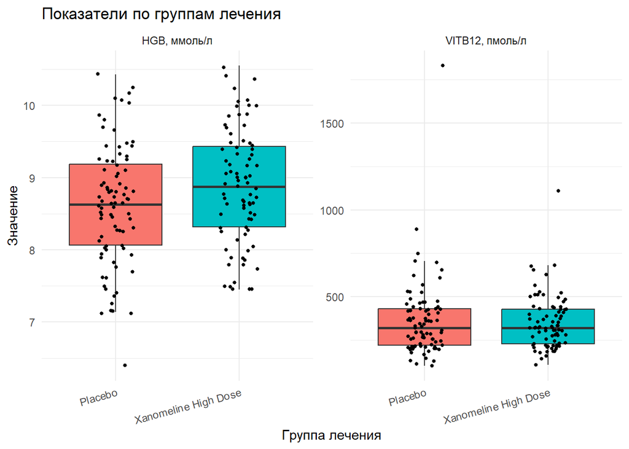

```r
# HGB и VITB12 by treatment
all_data |>
  pivot_longer(c(HGB, VITB12), names_to = "Показатель", values_to = "value") |>
  mutate(
    Показатель = recode(
      Показатель,
      HGB = "HGB, ммоль/л",
      VITB12 = "VITB12, пмоль/л"
    )
  ) |>

  ggplot(aes(x = ARM, y = value, fill = ARM)) +
  geom_boxplot(outlier.shape = NA) +
  geom_jitter(width = 0.15, size = 1) +
  facet_wrap(~Показатель, scales = "free_y") +
  labs(
    x = "Группа лечения",
    y = "Значение",
    title = "Показатели по группам лечения"
  ) +
  theme_minimal() +
  theme(
    legend.position = "none",
    axis.text.x = element_text(angle = 15, hjust = 1)
  )
```

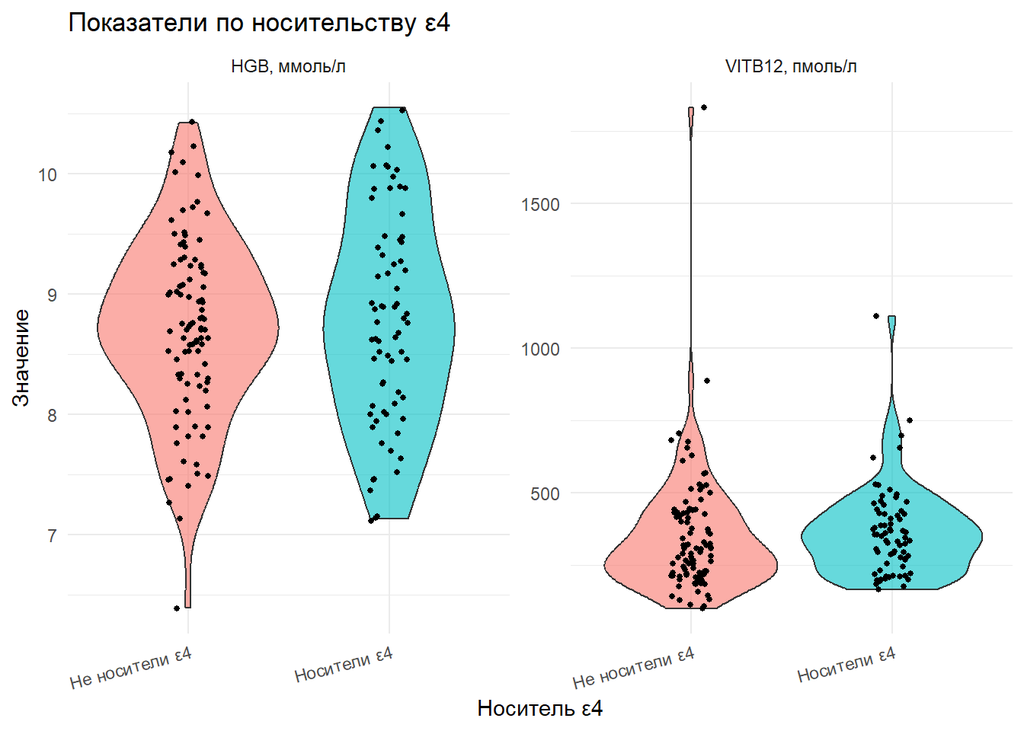

```r
# HGB и VITB12 by ε4
all_data |>
  pivot_longer(c(HGB, VITB12), names_to = "Показатель", values_to = "value") |>
  filter(!is.na(e4)) |>
  mutate(
    Показатель = recode(
      Показатель,
      HGB = "HGB, ммоль/л",
      VITB12 = "VITB12, пмоль/л"
    )
  ) |>

  ggplot(aes(x = e4, y = value, fill = e4)) +
  geom_violin(alpha = 0.6) +
  geom_jitter(width = 0.1, size = 1) +
  facet_wrap(~Показатель, scales = "free_y") +
  labs(
    x = "Носитель ε4",
    y = "Значение",
    title = "Показатели по носительству ε4"
  ) +
  theme_minimal() +
  theme(
    legend.position = "none",
    axis.text.x = element_text(angle = 15, hjust = 1)
  )
```

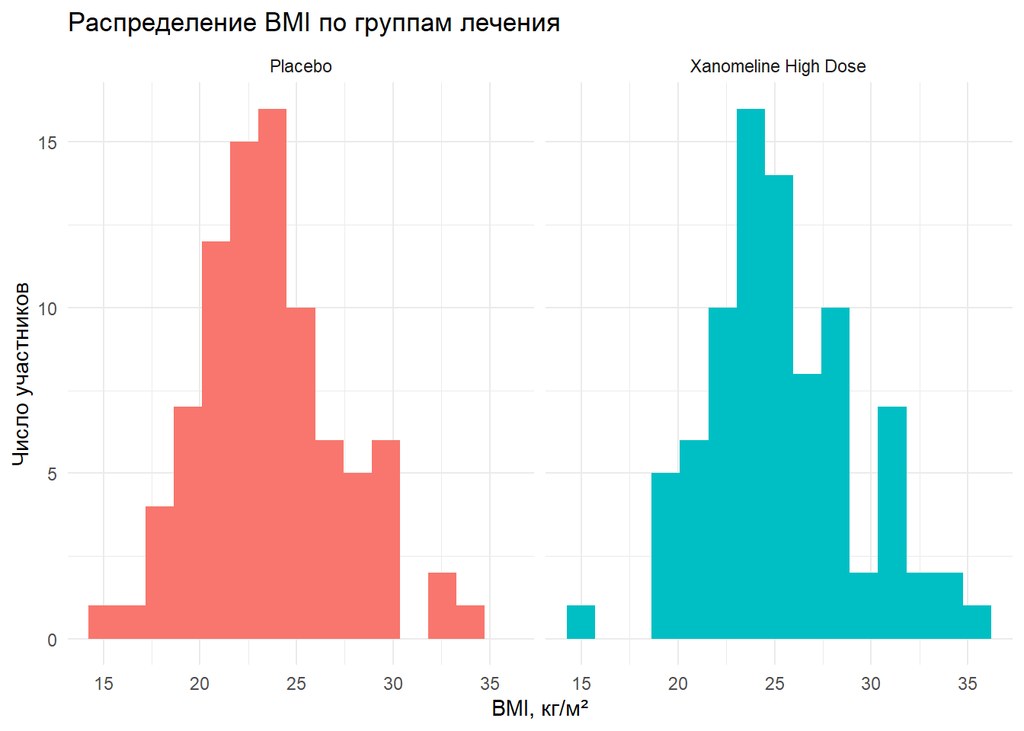

```r
#  BMIdistribution by treatment
ggplot(vika_all_data, aes(x = bmi, fill = ARM)) +
  geom_histogram(bins = 15, position = "identity") +
  facet_wrap(~ARM) +
  labs(
    x = "BMI, кг/м²",
    y = "Число участников",
    title = "Распределение BMI по группам лечения"
  ) +
  theme_minimal() +
  theme(legend.position = "none")
```

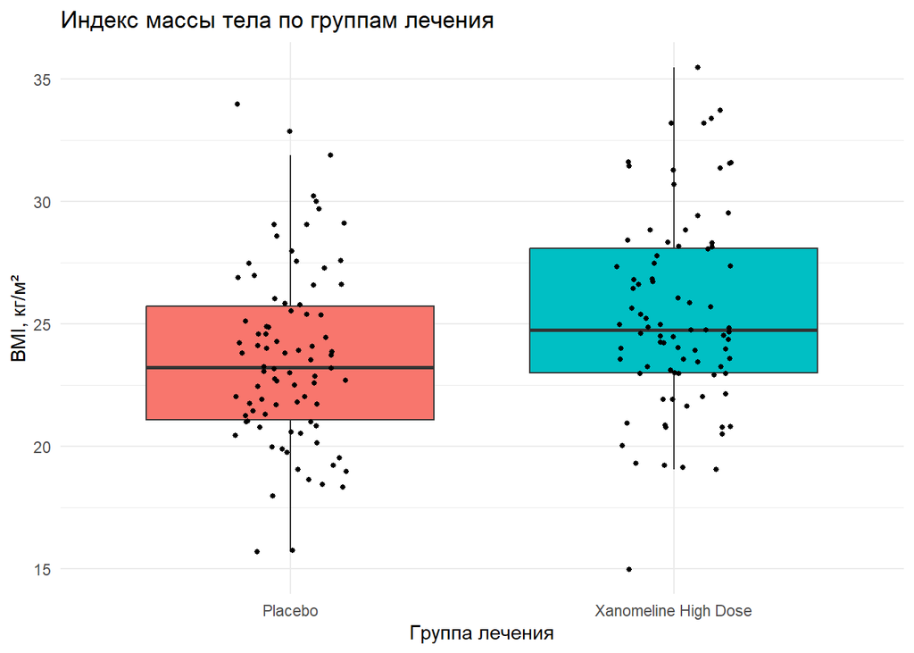

```r
# BMI by treatment boxplots
vika_all_data |>
  ggplot(aes(x = ARM, y = bmi, fill = ARM)) +
  geom_boxplot(outlier.shape = NA) +
  geom_jitter(width = 0.15, size = 1) +
  labs(
    x = "Группа лечения",
    y = "BMI, кг/м²",
    title = "Индекс массы тела по группам лечения"
  ) +
  theme_minimal() +
  theme(legend.position = "none")
```

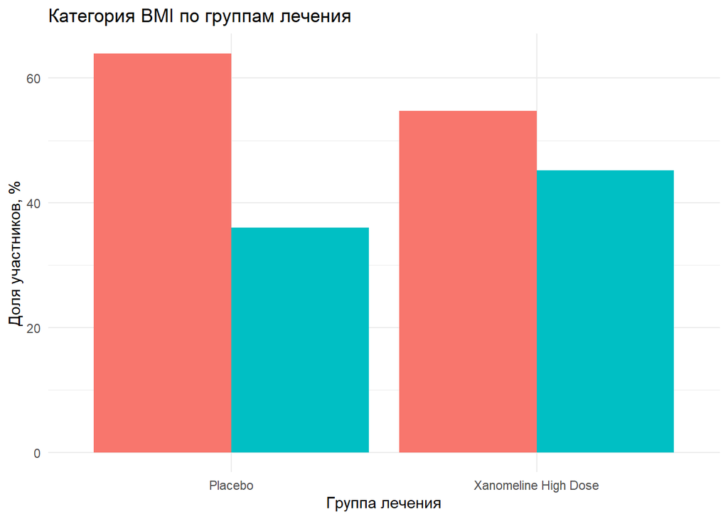

```r
# Normal/not normal BMI by treatment
vika_all_data |>
  count(ARM, bmi_cat) |>
  group_by(ARM) |>
  mutate(percent = n / sum(n) * 100) |>
  ggplot(aes(x = ARM, y = percent, fill = bmi_cat)) +
  geom_col(position = "dodge") +
  labs(
    x = "Группа лечения",
    y = "Доля участников, %",
    fill = "Категория BMI",
    title = "Категория BMI по группам лечения"
  ) +
  theme_minimal() +
  theme(legend.position = "none")
```

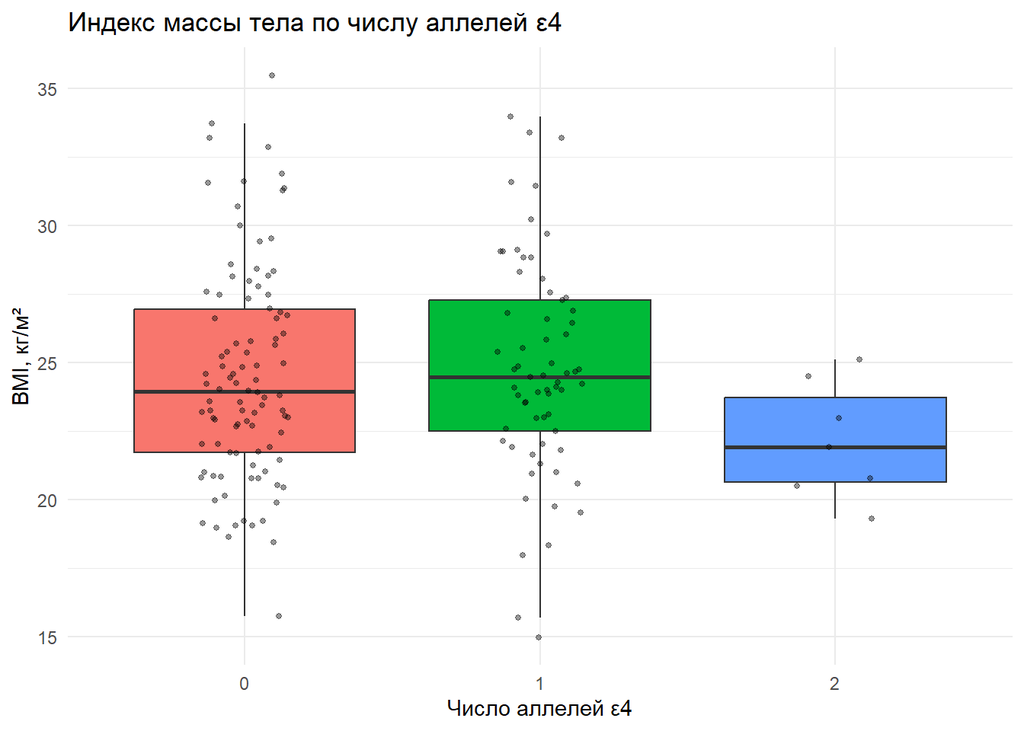

```r
# BMI by ε4 allele
vika_all_data |>
  filter(!is.na(num_ε4)) |>
  ggplot(aes(x = factor(num_ε4), y = bmi, fill = factor(num_ε4))) +
  geom_boxplot(outlier.shape = NA) +
  geom_jitter(width = 0.15, alpha = 0.4, size = 1) +
  labs(
    x = "Число аллелей ε4",
    y = "BMI, кг/м²",
    title = "Индекс массы тела по числу аллелей ε4"
  ) +
  theme_minimal() +
  theme(legend.position = "none")
```

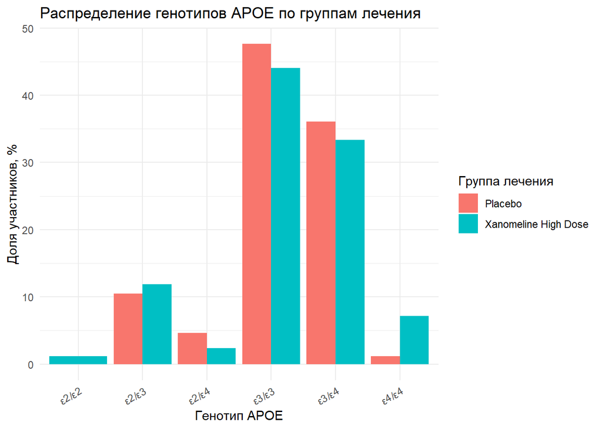

```r
# APOE genotype distribution by treatment
all_data |>
  count(ARM, apoe_genotype) |>
  group_by(ARM) |>
  mutate(percent = n / sum(n) * 100) |>
  ggplot(aes(x = apoe_genotype, y = percent, fill = ARM)) +
  geom_col(position = "dodge") +
  labs(
    x = "Генотип APOE",
    y = "Доля участников, %",
    fill = "Группа лечения",
    title = "Распределение генотипов APOE по группам лечения"
  ) +
  theme_minimal() +
  theme(axis.text.x = element_text(angle = 30, hjust = 1))
```

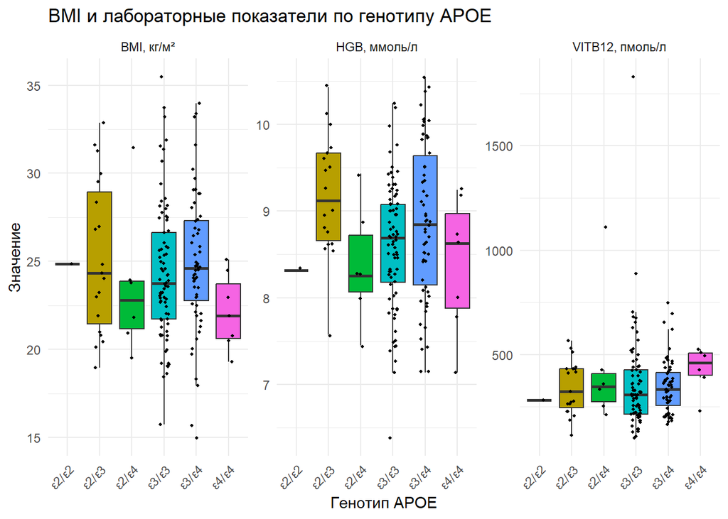

```r
# BMI, HGB and VITB12 by APOE genotype
all_data |>
  pivot_longer(
    c(BMI, HGB, VITB12),
    names_to = "Показатель",
    values_to = "value"
  ) |>
  mutate(
    Показатель = recode(
      Показатель,
      BMI = "BMI, кг/м²",
      HGB = "HGB, ммоль/л",
      VITB12 = "VITB12, пмоль/л"
    )
  ) |>

  ggplot(aes(x = apoe_genotype, y = value, fill = apoe_genotype)) +
  geom_boxplot(outlier.shape = NA) +
  geom_jitter(width = 0.15, size = 0.8) +
  facet_wrap(~Показатель, scales = "free_y") +
  labs(
    x = "Генотип APOE",
    y = "Значение",
    title = "BMI и лабораторные показатели по генотипу APOE"
  ) +
  theme_minimal() +
  theme(
    legend.position = "none",
    axis.text.x = element_text(angle = 45, hjust = 1)
  )
```

### 4.3. Заполнение пропущенных значений

Ветка `imputation`загружена на Git Hub.